# Ventas Gran Superficie

Objetivo: Predecir las ventas de cada producto para cada una de las tiendas de una cadena de supermercados.

## Esquema a seguir:

1 - Desarrollo de hipótesis  
2 - Exploración de datos  
3 - Limpieza de datos  
4 - Ingeniería de características  
5 - Creación de modelo

## 1 - Desarrollo de hipótesis:

Se expondrán hipótesis iniciales que se consideren que pueden aportar valor al análisis.  
Estas hipótesis es posible que no se puedan resolver por falta de datos.

**Hipótesis a nivel de tienda:**

Las tiendas de mayor superficie venden más al poder presentar los productos de manera más personalizada.  
Las tiendas con mayor variedad de productos venden más al atraer a mayor número de clientes y a la venta cruzada.  
Las tiendas en ciudades más importantes venden más debido a la mayor cantidad de clientes potenciales.  
Las tiendas con mayor antiguedad venden más al tener una mayor clientela fija.

**Hipótesis a nivel de producto:**

Se venden más los productos que se presentan en una mayor superficie de exposición.  
Se venden más los productos en oferta.  
Se venden más los productos de primeras marcas al aportar una mayor confianza al cliente.

## 2 - Exploración de datos

| Variable | Descripción |
| --- | --- |
| Item_Identifier | ID del producto (único) |
| Item_Weight | Peso del producto |
| Item_Fat_Content | Si el producto es bajo en grasa o no |
| Item_Visibility | El % del área de visualización total de todos los productos en una tienda asignada al producto en particular |
| Item_Type | La categoría a la que pertenece el producto. |
| Item_MRP | Precio máximo de venta al público (precio de lista) del producto |
| Outlet_Identifier | ID de la tienda (único) |
| Outlet_Establishment_Year | El año en que se estableció la tienda. |
| Outlet_Size | El tamaño de la tienda en términos de superficie cubierta. |
| Outlet_Location_Type | El tipo de ciudad en la que se encuentra la tienda. |
| Outlet_Type | Si la tienda es solo una tienda de comestibles o algún tipo de supermercado |
| Item_Outlet_Sales | Venta del producto en cada tienda. Esta es la variable a predecir. |

### Cargar datos

```r
# Nos aportan datos de entrenamiento y de test.

df_train <- read.csv('./data/Train_UWu5bXk.txt', na.strings = "")
df_test <- read.csv('./data/Test_u94Q5KV.txt', na.strings = "")
submission <- read.csv('./data/SampleSubmission_TmnO39y.txt', na.strings = "")

# Unificamos dataframe con entrenamiento y test para hacer features engineering
df_test$Item_Outlet_Sales <- 0
df <- rbind(df_train, df_test)
```

### Exploración de datos

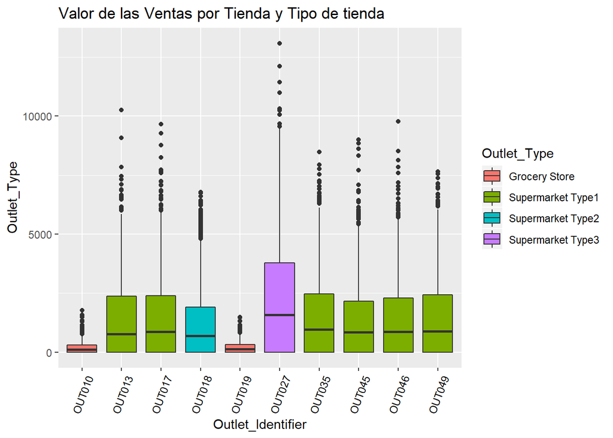

```r
ggplot(df, aes(Outlet_Identifier, Item_Outlet_Sales, fill  =  Outlet_Type)) +
  geom_boxplot() +
  theme(axis.text.x = element_text(angle = 70, vjust = 0.5, color = "black")) +
  xlab("Outlet_Identifier") +
  ylab("Outlet_Type") +
  ggtitle("Valor de las Ventas por Tienda y Tipo de tienda")
```

Podemos ver que las dos “Grocery Store” presentan el menor valor en ventas y la “Supermarket Type3” el mayor.

Tambien vemos que sólo existen una “Outlet_Type” “Supermarket Type2” y otra “Supermarket Type3”.

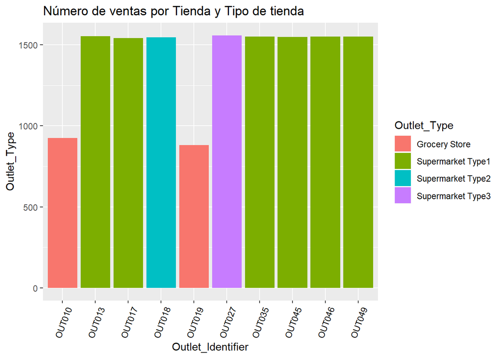

```r
ggplot(data = df) +
  geom_bar(mapping = aes(x = Outlet_Identifier, fill  =  Outlet_Type)) +
  theme(axis.text.x = element_text(angle = 70, vjust = 0.5, color = "black")) +
  xlab("Outlet_Identifier") +
  ylab("Outlet_Type") +
  ggtitle("Número de ventas por Tienda y Tipo de tienda")
```

No sólo en valor sino que también el menor número de ventas se corresponden a las “Grocery Store”.

Vemos que “Out027”, que corresponde a un “Supermarket Type3”, tiene la misma cantidad en número de ventas que los otros Superkarket pero como vimos en la gráfica anterior tiene un valor en ventas superior, esto nos hace pensar que los productos que vende son los más caros.

Veamos en cada tipo de tienda cuanto se vende de cada producto.

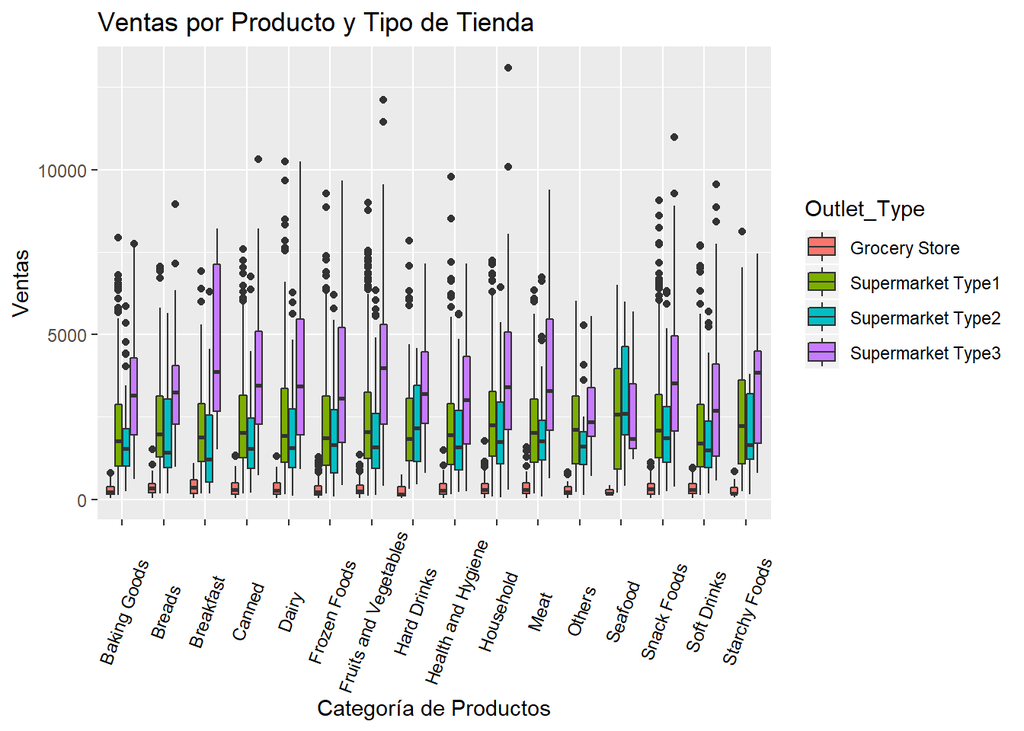

```r
ggplot(df[1:nrow(df_train),], aes(Item_Type, Item_Outlet_Sales, fill  =  Outlet_Type)) +
  geom_boxplot() +
  theme(axis.text.x = element_text(angle = 70, vjust = 0.5, color = "black")) +
  xlab("Categoría de Productos") +
  ylab("Ventas") +
  ggtitle("Ventas por Producto y Tipo de Tienda")
```

Comprobamos inequívocamente que los “Supermarket Type3” venden los productos más caros de cada una de las categorías a excepción de los “Seafoods”.

Si inspeccionamos los precios máximos de venta de los productos podemos apreciar cuatro rangos bastante diferenciados.

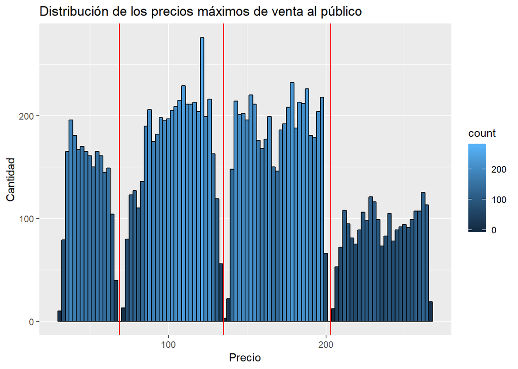

```r
ggplot(df, aes(Item_MRP)) +
  geom_histogram(bins = 100, color="black", aes(fill=..count..)) +
  geom_vline(xintercept = 69, color="red") +
  geom_vline(xintercept = 135, color="red") +
  geom_vline(xintercept = 203, color="red") +
  labs(title = "Distribución de los precios máximos de venta al público", x = "Precio", y = "Cantidad")
```

Podemos aprovechar estos rangos para crear una categoría de precios.

Ahora vamos a evaluar si existen valores nulos.

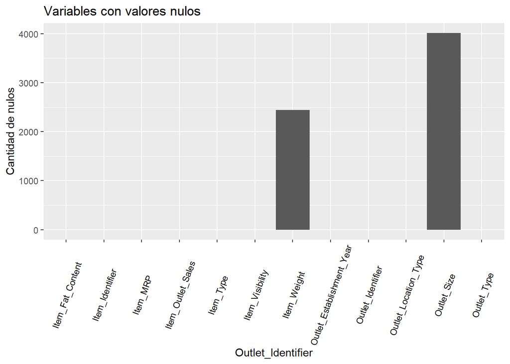

```r
nulos<- data.frame(sapply(df, function(x) sum(is.na(x))))
names(nulos) <- "valores_nulos"
nulos$variable <- rownames(nulos)

ggplot(nulos, aes(variable, valores_nulos)) +
  geom_col() +
  theme(axis.text.x = element_text(angle = 70, vjust = 0.5, color = "black")) +
  xlab("Outlet_Identifier") +
  ylab("Cantidad de nulos") +
  ggtitle("Variables con valores nulos")
```

Vamos a evaluar si existen registros con valor 0.

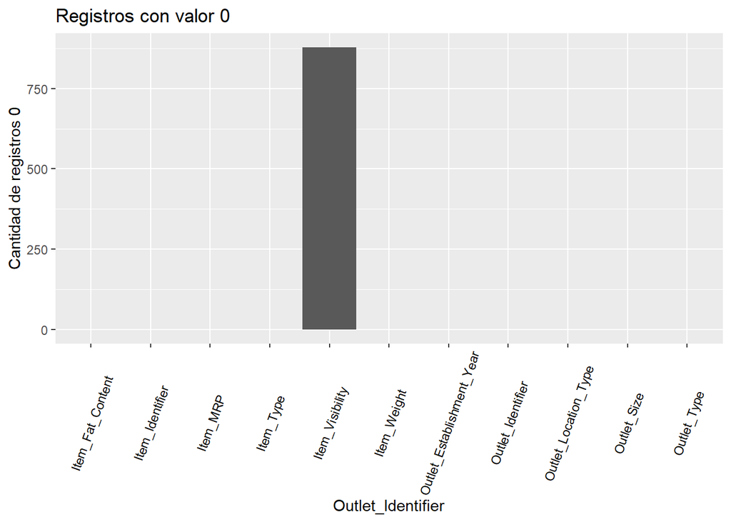

```r
ceros<- data.frame(sapply(df[-12], function(x) sum(x == 0, na.rm = T)))
names(ceros) <- "valores_cero"
ceros$variable <- rownames(ceros)

ggplot(ceros, aes(variable, valores_cero )) +
  geom_col() +
  theme(axis.text.x = element_text(angle = 70, vjust = 0.5, color = "black")) +
  xlab("Outlet_Identifier") +
  ylab("Cantidad de registros 0") +
  ggtitle("Registros con valor 0")
```

Se realiza una exploración del dataset para evaluar otras posibles anomalías.

```r
summary(df)
```

```
##  Item_Identifier  Item_Weight     Item_Fat_Content Item_Visibility
##  DRA24  :   10   Min.   : 4.555   LF     : 522     Min.   :0.00000
##  DRA59  :   10   1st Qu.: 8.710   low fat: 178     1st Qu.:0.02704
##  DRB25  :   10   Median :12.600   Low Fat:8485     Median :0.05402
##  DRC25  :   10   Mean   :12.793   reg    : 195     Mean   :0.06595
##  DRC27  :   10   3rd Qu.:16.750   Regular:4824     3rd Qu.:0.09404
##  DRC36  :   10   Max.   :21.350                    Max.   :0.32839
##  (Other):14144   NA's   :2439
##                  Item_Type       Item_MRP      Outlet_Identifier
##  Fruits and Vegetables:2013   Min.   : 31.29   OUT027 :1559
##  Snack Foods          :1989   1st Qu.: 94.01   OUT013 :1553
##  Household            :1548   Median :142.25   OUT035 :1550
##  Frozen Foods         :1426   Mean   :141.00   OUT046 :1550
##  Dairy                :1136   3rd Qu.:185.86   OUT049 :1550
##  Baking Goods         :1086   Max.   :266.89   OUT045 :1548
##  (Other)              :5006                    (Other):4894
##  Outlet_Establishment_Year Outlet_Size   Outlet_Location_Type
##  Min.   :1985              High  :1553   Tier 1:3980
##  1st Qu.:1987              Medium:4655   Tier 2:4641
##  Median :1999              Small :3980   Tier 3:5583
##  Mean   :1998              NA's  :4016
##  3rd Qu.:2004
##  Max.   :2009
##
##             Outlet_Type   Item_Outlet_Sales
##  Grocery Store    :1805   Min.   :    0.0
##  Supermarket Type1:9294   1st Qu.:    0.0
##  Supermarket Type2:1546   Median :  559.3
##  Supermarket Type3:1559   Mean   : 1308.9
##                           3rd Qu.: 2163.2
##                           Max.   :13087.0
##
```

Se confirma que tenemos valores nulos en:  
- “Item_Weight” los pesos de los productos.  
- “Outlet_Size” el tamaño de la tienda.

En “Item_Visibility” tenemos productos que no tienen area de visión en la tienda, se ha de deber a un fallo pues no puede haber productos que se vendan sin estar en exposición.

En “Item_Fat_Content” hay varias nomenclaturas que se refieren al mismo concepto, habrá que regularizarlas.

## 3 - Limpieza de los datos

### Completar los NA de “Outlet_Size”

Se inspecciona la relación del tipo de establecimiento “Outlet_Type” con su tamaño “Outlet_Size”.

```r
table(df$Outlet_Type, df$Outlet_Size)
```

```
##
##                     High Medium Small
##   Grocery Store        0      0   880
##   Supermarket Type1 1553   1550  3100
##   Supermarket Type2    0   1546     0
##   Supermarket Type3    0   1559     0
```

Es evidente que las “Grocery Store” tienen un tamaño “Small”, “Supermarket Type2” y “Supermarket Type3” tienen tamaño “Medium”.  
Supermarket Type1 tiene valores “High”, “Medium” y “Small”.

Asignamos los valores para “Grocery Store”, “Supermarket Type2” y “Supermarket Type3”.

```r
df$Outlet_Size[df$Outlet_Type == "Grocery Store"]  <- "Small"
df$Outlet_Size[df$Outlet_Type == "Supermarket Type2"] <- "Medium"
df$Outlet_Size[df$Outlet_Type == "Supermarket Type3"] <- "Medium"
```

Nos quedaría determinar los tamaños para los “Supermarket Type1”, donde nos podemos fijar en “Outlet_Location_Type” tipo de ciudad donde están ubicadas las tiendas.

```r
df_type1 <- filter(df, Outlet_Type == "Supermarket Type1")
table(df_type1$Outlet_Location_Type, df_type1$Outlet_Size)
```

```
##
##          High Medium Small
##   Tier 1    0   1550  1550
##   Tier 2    0      0  1550
##   Tier 3 1553      0     0
```

Se aprecia que para las tiendas de tipo “Supermarket Type1”, “Tier 2” es “Small” y “Tier 3” es “High”

Asignamos los valores para “Tier 2” y “Tier 3”

```r
df$Outlet_Size[df$Outlet_Type == "Supermarket Type1" & df$Outlet_Location_Type == "Tier 2"]  <- "Small"
df$Outlet_Size[df$Outlet_Type == "Supermarket Type1" & df$Outlet_Location_Type == "Tier 3"]  <- "High"
```

Evaluamos si quedan NA, de ser así tendrán que ser de “Tier 1”, pero al evaluar “Outlet_Size” se puede apreciar que no hay NA.

```r
table(is.na(df$Outlet_Size))
```

```
##
## FALSE
## 14204
```

### Completar los NA de “Item_Weight”

Inspeccionamos los pesos de los productos y como era de esperar todos los productos tienen el mismo peso para la misma referencia de producto.

```r
head(by(df$Item_Weight, df$Item_Identifier, FUN = summary),3)
```

```
## $DRA12
##    Min. 1st Qu.  Median    Mean 3rd Qu.    Max.    NA's
##    11.6    11.6    11.6    11.6    11.6    11.6       1
##
## $DRA24
##    Min. 1st Qu.  Median    Mean 3rd Qu.    Max.    NA's
##   19.35   19.35   19.35   19.35   19.35   19.35       2
##
## $DRA59
##    Min. 1st Qu.  Median    Mean 3rd Qu.    Max.    NA's
##    8.27    8.27    8.27    8.27    8.27    8.27       2
```

Completamos los pesos faltantes a partir de los pesos de su misma referencia.

```r
by_weight <- df %>%
  group_by(Item_Identifier) %>%
  summarise(peso = mean(Item_Weight, na.rm = TRUE))

for (i in 1:nrow(df) ) {
  df[i,2] <- by_weight$peso[df[i,1] == by_weight$Item_Identifier]
}
```

### Completar valores 0 apreciados en “Item_Visibility”

Vamos a inspeccionar el comportamiento de “Item_Visibility”.

La estrategia que se pretende seguir es, para un mismo producto buscar otro expuesto en una tienda con las mismas características.  
Como variables interesantes para la clasificación de las caracteristicas de las tiendas encontramos:  
- “Outlet_Size” el tamaño de la tienda.  
- “Outlet_Type” el tipo de tienda comestible/supermercado.

Ya vimos en el tratamiento de los “Outlet_Size” faltantes que:  
- Las tiendas “Grocery Store” siempre son “Outlet_Size” “Small”.  
- Las tiendas “Supermarket Type2” y “Supermarket Type3” siempre son “Medium”  
Por lo que el “Supermarket Type1” es el único que nos podría aportar algún valor extra en función de si tiene “Outlet_Size” “Small”, “Medium” o “High”.

Esto es una presentación de uno de los productos que tiene uno de sus “Item_Visibility” con valor 0.

```r
item_v <- unique(filter(df, Item_Visibility == 0) %>% select(Item_Identifier)) #Productos que tienen al menos un "item_Visibility" con valor 0.

item_v <- filter(df, df$Item_Identifier %in% item_v$Item_Identifier)

select(item_v, Item_Identifier, Item_Visibility, Outlet_Size, Outlet_Type) %>% filter(Item_Identifier =="FDN15") # Ejemplo de un producto con Item_Visibility a 0.
```

```
##    Item_Identifier Item_Visibility Outlet_Size       Outlet_Type
## 1            FDN15      0.01676007      Medium Supermarket Type1
## 2            FDN15      0.02800938       Small     Grocery Store
## 3            FDN15      0.01672013        High Supermarket Type1
## 4            FDN15      0.01680223      Medium Supermarket Type2
## 5            FDN15      0.01676800       Small Supermarket Type1
## 6            FDN15      0.02929918       Small     Grocery Store
## 7            FDN15      0.01665302      Medium Supermarket Type3
## 8            FDN15      0.01673089       Small Supermarket Type1
## 9            FDN15      0.01682871       Small Supermarket Type1
## 10           FDN15      0.00000000       Small Supermarket Type1
```

“Outlet_Size” no nos está aportando mucho valor pues podemos ver que tiendas con valor “small” tienen un “Item_Visibility” bastante mayor unas respecto a otras.

Lo que si podemos ver es que “Outler_Type” = “Grocery Store” difiere en gran medida repecto a cualquier otro valor de “Outlet_Type” por lo que se unificarán las categorias “Supermarket Type1”, “Supermarket Type2” y “Supermarket Type3” en “Supermarket Type123”.

Completaremos los valores 0 de “Item_Visibility” con promedios del mismo producto según pertenezca a “Grocery Store” o “Supermarket Type123”.

Vamos a calcular las medias de los “Item_Visibility” por producto y agrupados por “Supermarket Type123” y “Grocery Store”.

```r
df$Outlet_Type2 <- ifelse (df$Outlet_Type == "Grocery Store",
                           "Grocery Store", "Supermarket Type123")

df$Outlet_Type2 <- factor(df$Outlet_Type2)
medias <- group_by(df,
                   Item_Identifier, Outlet_Type2) %>%
                   mutate(Mean_Visibility = mean(Item_Visibility[Item_Visibility != 0] )) %>%

                   select(Item_Identifier, Item_Visibility, Outlet_Type, Mean_Visibility)
summary(medias$Mean_Visibility)
```

```
##    Min. 1st Qu.  Median    Mean 3rd Qu.    Max.    NA's
## 0.00360 0.03135 0.05793 0.07033 0.09771 0.32578      40
```

```r
head(medias)
```

```
## # A tibble: 6 x 5
## # Groups:   Item_Identifier, Outlet_Type2 [6]
##   Outlet_Type2  Item_Identifier Item_Visibility Outlet_Type Mean_Visibility
##   <fct>         <fct>                     <dbl> <fct>                 <dbl>
## 1 Supermarket ~ FDA15                    0.0160 Supermarke~          0.0160
## 2 Supermarket ~ DRC01                    0.0193 Supermarke~          0.0192
## 3 Supermarket ~ FDN15                    0.0168 Supermarke~          0.0168
## 4 Grocery Store FDX07                    0      Grocery St~        NaN
## 5 Supermarket ~ NCD19                    0      Supermarke~          0.0132
## 6 Supermarket ~ FDP36                    0      Supermarke~          0.0913
```

Inspeccionando los resultados podemos apreciar que tenemos 40 NaN de valores de “Grocery Store” donde no había ningún otro valor de “Grocery Store” con el que realizar la media.

Como pudimos comprobar anteriormente los “Item_Visibility” para tiendas “Grocery Store” tienen un valor mayor con respecto a “Supermarket Type123”.

Todos los valores NaN tienen como “Outlet_Type” “Grocery Store”.

Completaremos esos NaN aplicandole la media de calcular el factor de incremento de los productos “Supermarket Type123” con respecto a “Grocery Store”.

```r
# Se seleccionan los productos que tengan valores de Item_Visibility para "Supermarket Type123" y "Grocery Store".
# Estos valores se utilizarán para hallar el factor de cuanto se incrementa "Grocery Store" con respecto a "Supermarket Type123".
lista_factor_grocery <- select(df,
                               Item_Identifier, Item_Visibility, Outlet_Type2) %>%
                               filter(Item_Visibility != 0) %>%
                               select(Item_Identifier, Outlet_Type2)

lista_factor_grocery <- unique(lista_factor_grocery)
lista_factor_grocery <- filter(lista_factor_grocery,
                               Outlet_Type2 == "Grocery Store")

# Se filtran en el dataframe "medias" que contiene la media de Item_Visibility por producto con los productos de lista_factor_grocery.
lista_factor_grocery <- select(medias,
                               Outlet_Type2, Item_Identifier, Mean_Visibility) %>%
                               filter(Item_Identifier %in% lista_factor_grocery$Item_Identifier) %>%
                               ungroup() %>%
                               select(Item_Identifier, Mean_Visibility)

lista_factor_grocery <- unique(lista_factor_grocery)

lista_factor_grocery <- group_by(lista_factor_grocery,
                                 Item_Identifier) %>%
                                 mutate(factor = max(Mean_Visibility)/min(Mean_Visibility))

factor_grocery <- mean(lista_factor_grocery$factor)

sprintf("Las tiendas con Outlet_Type igual a Grocery Store tienen un area de visualización promedio de %f veces mayor con respecto a las de tipo Supermarket", factor_grocery)
```

```
## [1] "Las tiendas con Outlet_Type igual a Grocery Store tienen un area de visualización promedio de 1.709449 veces mayor con respecto a las de tipo Supermarket"
```

Vamos a aplicar el factor a los 40 NaN

```r
medias$Item_Identifier <- as.character(medias$Item_Identifier)

for (i in 1:nrow(medias)){
  if (as.character(medias[i,5]) == "NaN") {
    filtrado <- filter(medias, Outlet_Type2 != "Grocery Store") %>%
                filter(Item_Identifier == as.character(medias[i,2]))

    medias[i,5] <- filtrado[1,5]*factor_grocery
  }
}

df$medias <- medias$Mean_Visibility

for (i in 1:nrow(df)) {
  if(df[i,4] == 0)
    df[i,4] <- df[i,14]
}
```

### Regularizar las categorias de “Item_Fat_Content”

Vamos a unificar las categorías que se refieren a si el producto es bajo en grasa o no.

```r
table(df$Item_Fat_Content)
```

```
##
##      LF low fat Low Fat     reg Regular
##     522     178    8485     195    4824
```

Convertiremos los conceptos LF, low flat en Low Fat y reg en Regular.

```r
df$Item_Fat_Content <- factor(plyr::revalue(df$Item_Fat_Content,
                               c("LF" = "Low Fat", "low fat" = "Low Fat", "reg" = "Regular")))
table(df$Item_Fat_Content)
```

```
##
## Low Fat Regular
##    9185    5019
```

## 4- Ingeniería de características:

Ahora que tenenemos limpios los datos vamos a crear nuevas variables esperando que aporten algún valor a la hora de la predicción.

### Crear variable tipo de producto “cat_prod”.

Si nos fijamos en “Item_Identifier” apreciamos que las dos primeras letras de las categorias corresponden a DR, FD, NC.  
Podemos crear una nueva variable “cat_prod”: categoría productos, pues corresponden a:

DR: bebida.  
FD: comestible.  
NC: no comestible.

```r
#df$Item_Identifier <- as.character(df$Item_Identifier)
df$cat_prod <- apply(df[1],2, function(x){substr(x,1,2) })
df$cat_prod <- factor(df$cat_prod)
```

Ahora que sabemos que “NC” corresponde a producto no comestible podemos afinar mejor la definición de “Item_Fat_Content” añadiendo la categoría “Fat Free” para los productos “NC” de “cat_prod”.

### Crear variable tipo de producto “cat_prod2”.

A modo de enriquecer los datos vamos a crear una nueva variable con las tres primeras letras del código de los productos en “Item_Identifier”, con esto esperamos obtener una mayor granularidad.

```r
#df$Item_Identifier <- as.character(df$Item_Identifier)
df$cat_prod2 <- apply(df[1],2, function(x){substr(x,1,3) })
df$cat_prod2 <- factor(df$cat_prod2)
```

### Crear variable “years”.

Vamos a crear la variable “years” con la antigüedad de la tienda.  
Tenemos que contar con que se nos han proporcionado datos que corresponden al año 2013.

```r
df$years <- 2013 - df$Outlet_Establishment_Year
```

### Crear variable "Price_ _Range"

Creamos la variable “Price_range” con los rangos de precios detectados en la fase de exploración.

```r
df$Price_Range <- 0
df[,"Price_Range"] <- cut(df$Item_MRP, breaks = c(0,69,135,203, Inf), labels = c("Precio Bajo", "Precio Medio", "Precio Alto", "Precio Maximo"))
```

```r
df_modelo <- select(df,
                    #Item_Weight,
                    #Item_Fat_Content,
                    #Item_Visibility,
                   # Item_Type,
                    Item_MRP,
                    Outlet_Identifier,
                    Outlet_Size,
                    #Outlet_Location_Type,
                    Outlet_Type,
                    Outlet_Type2,
                    #cat_prod,
                    #cat_prod2,
                    #years,
                    #Price_Range,
                    Item_Outlet_Sales
                    )
```

## 5 - Creación de modelo

Primero vamos a prepara el dataset.  
Vamos a dividir el dataset como originalmente se nos entregó, las 8523 primeras observaciones para entrenamiento y las 5681 restantes para test.

```r
df_modelo_train <- df_modelo[1:8523,]
df_modelo_test <- df_modelo[8524:nrow(df),-16]
```

```r
# library(caTools) #cargar paquete para dividir dataset
# set.seed(123)
# split <- sample.split(df_modelo_train$Item_Outlet_Sales, SplitRatio = 0.75) #dividir dataset
# training_set <- subset(df_modelo_train, split == TRUE)
# testing_set <- subset(df_modelo_train, split == FALSE)
```

### SVM

```r
library(e1071)

#Obtener valores optimos para sigma y cost.
classifier <- train(form =Item_Outlet_Sales ~ .,
                    data = df_modelo_train, method = "svmRadial")
classifier$bestTune
```

```
##        sigma C
## 3 0.05871369 1
```

```r
classifier$finalModel
```

```
## Support Vector Machine object of class "ksvm"
##
## SV type: eps-svr  (regression)
##  parameter : epsilon = 0.1  cost C = 1
##
## Gaussian Radial Basis kernel function.
##  Hyperparameter : sigma =  0.0587136881061947
##
## Number of Support Vectors : 6561
##
## Objective Function Value : -2986.692
## Training error : 0.394689
```

```r
#aplicar la SMV
regression = svm(formula = Item_Outlet_Sales ~ .,
                 data = df_modelo_train,
                 type = "eps-regression",
                 kernel = "radial",
                 kpar = list(sigma = 0.106463),
                 C = 0.5)

y_pred = as.data.frame(predict(regression, newdata = df_modelo_test))
```

Conclusión:

Datos del hackaton de Data Scientist:  
- Total de participantes: 2500.  
- El ganador obtuvo una puntuación de 1128.  
- Con este análisis se ha obtenido una puntuación de 1148.  
- Puesto obtenido 250/2500.

Opciones de mejora:

- Explorar un mayor ajuste de la SVM.
- Creación de nuevas características.
- Probar algoritmos alternativos como Random Forest o XGB.